# Banchereau, et al. cell type analyses with recount2 model

**J. Taroni 2018**

In `06-sle-wb_cell_type`, we examined how LVs from the SLE WB PLIER model (`results/05/SLE-WB_PLIER_model.RDS`) compared to known patterns in the [Banchereau, et al.](https://doi.org/10.1016/j.cell.2016.03.008) data set that was included in the SLE WB compendium (and therefore, training).

Specifically, we asked:

- Are there neutrophil-associated LVs that are correlated with neutrophil counts?
- Are there plasma cell-associated LVs that demonstrate differential expression between disease activity groups (specifically, higher values in more severe disease)?

The answer to both of these questions is yes. This demonstrated the utility of PLIER for extracting cell type patterns from heterogeneous (at least in terms of patient population and platform) gene expression data from a single tissue (whole blood) that had been assembled into a compendium ([`greenelab/rheum-plier-data/sle-wb`](https://github.com/greenelab/rheum-plier-data/tree/4be547553f24fecac9e2f5c2b469a17f9df253f0/sle-wb)).

SLE is not a rare condition – though the molecular heterogeneity and multi-tissue nature of the disease warrant sophisticated approaches to the analysis of transcriptomic data. (This SLE WB compendium is comprised of 1640 samples and is *incomplete*; we picked 7 data sets based on the platform used and the availability of raw data.) Thus, we can use data-intensive approaches (e.g., PLIER) that are inappropriate for smaller data sets and, by extension, rare or understudied diseases.

Using a “shovel-ready” data set like [recount2](https://jhubiostatistics.shinyapps.io/recount/) to train a PLIER model (see [`greenelab/rheum-plier-data/recount2`](https://github.com/greenelab/rheum-plier-data/tree/4be547553f24fecac9e2f5c2b469a17f9df253f0/recount2)) and applying this model to smaller data sets may “get around” the data-intensive requirement, but more investigation is warranted.

In this notebook, we examine whether we can use the recount2 PLIER model (`data/recount2_PLIER_data/recount_PLIER_model.RDS`) to analyze neutrophil and plasma cell patterns in the Banchereau, et al. data. If the recount2 model performance is similar to that of the SLE model (examined in `06-sle-wb_cell_type`), that is evidence supporting the validity of this transfer learning approach.

## Functions and directory set up

```r
`%>%` <- dplyr::`%>%`
library(PLIER)
# custom functions
source(file.path("util", "plier_util.R"))
```

```r
# plot and result directory setup for this notebook
plot.dir <- file.path("plots", "07")
dir.create(plot.dir, recursive = TRUE, showWarnings = FALSE)
results.dir <- file.path("results", "07")
dir.create(results.dir, recursive = TRUE, showWarnings = FALSE)
```

## Load data

### recount2 model

```r
recount.plier <- readRDS(file.path("data", "recount2_PLIER_data",
                                   "recount_PLIER_model.RDS"))
```

### SLE WB expression data

```r
symbol.file <-
  file.path("data", "expression_data",
            "SLE_WB_all_microarray_QN_zto_before_with_GeneSymbol.pcl")
sle.exprs.df <- readr::read_tsv(symbol.file, progress = FALSE)
# matrix with gene symbol as rownames
exprs.mat <- dplyr::select(sle.exprs.df, -EntrezID)
rownames(exprs.mat) <- exprs.mat$GeneSymbol
```

```
Setting row names on a tibble is deprecated.
```

```r
exprs.mat <- as.matrix(dplyr::select(exprs.mat, -GeneSymbol))
```

### SLE WB cell type LV dfs

From `06-sle-wb_cell_type`

```r
neutro.file <- file.path("results", "06",
                         "Banchereau_count_SLE_model_neutrophil_LV.tsv")
sle.neutro.df <- readr::read_tsv(neutro.file)
plasma.file <- file.path("results", "06",
                         "Banchereau_DA_group_SLE_model_plasma_cell_LVs.tsv")
sle.plasma.df <- readr::read_tsv(plasma.file)
```

## Cell type-associated LVs in the recount2 model

```r
# summary information from the recount2 PLIER model
recount.summary <- recount.plier$summary
```

### Neutrophil

Are there recount2 LVs associated with neutrophil gene sets?

```r
recount.summary %>%
  dplyr::filter(grepl("Neutrophil", pathway),
                FDR < 0.05)
```

| pathway | LV index | AUC | p-value | FDR |
| --- | --- | --- | --- | --- |
| IRIS_Neutrophil-Resting | 7 | 0.7006335 | 6.673189e-11 | 2.937565e-09 |
| SVM Neutrophils | 61 | 0.6470668 | 4.685830e-04 | 4.059171e-03 |
| IRIS_Neutrophil-Resting | 68 | 0.5992759 | 8.742389e-04 | 7.010161e-03 |
| SVM Neutrophils | 140 | 0.7322644 | 1.615458e-03 | 1.131345e-02 |
| IRIS_Neutrophil-Resting | 172 | 0.7181366 | 9.853404e-13 | 5.864498e-11 |
| IRIS_Neutrophil-Resting | 524 | 0.7568178 | 5.595607e-16 | 5.747488e-14 |
| SVM Neutrophils | 524 | 0.9585456 | 2.422192e-10 | 9.166086e-09 |
| IRIS_Neutrophil-Resting | 603 | 0.9057506 | 8.355936e-38 | 4.505939e-35 |
| SVM Neutrophils | 603 | 0.9797889 | 2.856571e-11 | 1.432936e-09 |
| IRIS_Neutrophil-Resting | 675 | 0.7298004 | 1.073918e-12 | 5.939594e-11 |

[output cut: 2 more lines]

The following latent variables look most promising: `LV524`, `LV603`, `LV985` (`AUC > 0.75` for both `SVM Neutrophils` and `IRIS_Neutrophil-Resting`)

What other gene sets are associated with these LVs?

```r
recount.summary %>%
  dplyr::filter(`LV index` %in% c(524, 603, 985),
                FDR < 0.05) %>%
  dplyr::arrange(`LV index`, desc(AUC))
```

| pathway | LV index | AUC | p-value | FDR |
| --- | --- | --- | --- | --- |
| SVM Neutrophils | 524 | 0.9585456 | 2.422192e-10 | 9.166086e-09 |
| SVM Monocytes | 524 | 0.7837563 | 1.206838e-04 | 1.295099e-03 |
| IRIS_Neutrophil-Resting | 524 | 0.7568178 | 5.595607e-16 | 5.747488e-14 |
| DMAP_MONO1 | 524 | 0.6794939 | 1.266862e-03 | 9.326355e-03 |
| DMAP_MONO2 | 524 | 0.6375777 | 4.974107e-03 | 2.662320e-02 |
| SVM Neutrophils | 603 | 0.9797889 | 2.856571e-11 | 1.432936e-09 |
| IRIS_Neutrophil-Resting | 603 | 0.9057506 | 8.355936e-38 | 4.505939e-35 |
| PID_IL8CXCR2_PATHWAY | 603 | 0.8107324 | 8.814671e-04 | 7.041943e-03 |
| SIG_PIP3_SIGNALING_IN_B_LYMPHOCYTES | 603 | 0.7692918 | 3.387907e-03 | 1.948724e-02 |
| SIG_PIP3_SIGNALING_IN_B_LYMPHOCYTES | 985 | 0.7802218 | 4.565601e-03 | 2.499493e-02 |

[output cut: 3 more lines]

Some notes on these results:

- `LV524` is also associated with the following monocyte-related gene sets: `SVM Monocytes`, `DMAP_MONO1`, and `DMAP_MONO2`. Again, we would like something that tells us about neutrophils *only* if at all possible.
- `LV603` is associated with two other gene sets, [`PID_IL8CXCR2_PATHWAY`](http://software.broadinstitute.org/gsea/msigdb/cards/PID_IL8_CXCR2_PATHWAY.html) and [`SIG_PIP3_SIGNALING_IN_B_LYMPHOCYTES`](http://software.broadinstitute.org/gsea/msigdb/cards/SIG_PIP3_SIGNALING_IN_B_LYMPHOCYTES.html). It’s worth noting that interleukin 8 (`IL8`) is a neutrophil chemoattractant, and `SIG_PIP3_SIGNALING_IN_B_LYMPHOCYTES` [may just be related](http://software.broadinstitute.org/gsea/msigdb/compute_overlaps.jsp?geneSetName=SIG_PIP3_SIGNALING_IN_B_LYMPHOCYTES&collection=C2) to PI3K signaling & chemotaxis in general.
- `LV985` is also associated with `SIG_PIP3_SIGNALING_IN_B_LYMPHOCYTES` and [`PID_FCER1PATHWAY`](http://software.broadinstitute.org/gsea/msigdb/cards/PID_FCER1_PATHWAY.html). `FCER1` refers to Fc-epsilon receptor 1 which is mainly expressed on other granulocytes.

#### U matrix

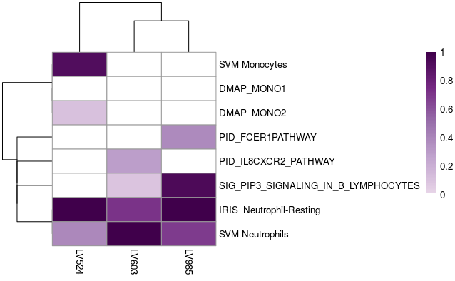

```r
PLIER::plotU(plierRes = recount.plier,
             pval.cutoff = 1e-06,
             indexCol = c(524, 603, 985),
             top = 10)
```

```r
png(file.path(plot.dir, "recount2_neutrophil_Uplot.png"),
    res = 300, width = 7, height = 7, units = "in")
PLIER::plotU(plierRes = recount.plier,
             pval.cutoff = 1e-06,
             indexCol = c(524, 603, 985),
             top = 10)
dev.off()
```

### Plasma cell

Are there LVs associated with plasma cell gene sets in the recount2 model?

```r
recount.summary %>%
  dplyr::filter(grepl("Plasma", pathway),
                FDR < 0.05)
```

| pathway | LV index | AUC | p-value | FDR |
| --- | --- | --- | --- | --- |
| IRIS_PlasmaCell-FromBoneMarrow | 951 | 0.7866485 | 2.417848e-10 | 9.166086e-09 |
| IRIS_PlasmaCell-FromPBMC | 951 | 0.6799715 | 1.659749e-04 | 1.704799e-03 |
| SVM Plasma cells | 951 | 0.7971633 | 2.357811e-05 | 3.101096e-04 |

What other gene sets are associated with `LV951`?

```r
recount.summary %>%
  dplyr::filter(`LV index` == 951)
```

| pathway | LV index | AUC | p-value | FDR |
| --- | --- | --- | --- | --- |
| IRIS_PlasmaCell-FromBoneMarrow | 951 | 0.7866485 | 2.417848e-10 | 9.166086e-09 |
| IRIS_PlasmaCell-FromPBMC | 951 | 0.6799715 | 1.659749e-04 | 1.704799e-03 |
| SVM Plasma cells | 951 | 0.7971633 | 2.357811e-05 | 3.101096e-04 |
| KEGG_INTESTINAL_IMMUNE_NETWORK_FOR_IGA_PRODUCTION | 951 | 0.6842137 | 3.776986e-02 | 1.270977e-01 |

`KEGG_INTESTINAL_IMMUNE_NETWORK_FOR_IGA_PRODUCTION` is not a significant association (`FDR = 0.13`) There were 2 LVs from the SLE WB PLIER model that were associated with plasma cell gene sets. Those LVs were also associated with other processes (e.g., `REACTOME_UNFOLDED_PROTEIN_RESPONSE`, `KEGG_HEDGEHOG_SIGNALING_PATHWAY`)

## Transform SLE WB data

```r
sle.recount.b <- GetNewDataB(exprs.mat = exprs.mat,
                             plier.model = recount.plier)
b.file <- file.path(results.dir, "SLE-WB_B_matrix_recount2_model.RDS")
saveRDS(sle.recount.b, file = b.file)
```

## Banchereau, et al. cell type results

### Neutrophil

```r
neutro.lv.df <- as.data.frame(cbind(colnames(sle.recount.b),
                                    t(sle.recount.b[c(524, 603, 985), ])))
colnames(neutro.lv.df) <- c("Sample", "recount2_LV524", "recount2_LV603",
                            "recount2_LV985")
```

```r
# join with sle wb results & neutrophil counts
neutro.df <- dplyr::inner_join(sle.neutro.df, neutro.lv.df) %>%
              dplyr::mutate(recount2_LV524 = as.numeric(as.character(recount2_LV524)),
                            recount2_LV603 = as.numeric(as.character(recount2_LV603)),
                            recount2_LV985 = as.numeric(as.character(recount2_LV985)))
```

```
Column `Sample` joining character vector and factor, coercing into character vector
```

```r
head(neutro.df)
```

| Sample | LV2 | LV27 | LV34 | LV87 | Neutrophil.Count | recount2_LV524 | recount2_LV603 | recount2_LV985 |
| --- | --- | --- | --- | --- | --- | --- | --- | --- |
| GSM1594269 | 0.011861389 | 0.26673596 | -0.19054906 | 0.22312980 | 5.68 | -0.0022979934 | 0.04077837 | -0.01605975 |
| GSM1594270 | 0.006286237 | -0.11669503 | 0.12317157 | -0.25853972 | 1.73 | -0.0135437736 | -0.03407449 | 0.04967700 |
| GSM1594271 | 0.101034911 | 0.23906176 | 0.66767432 | 0.45530554 | 4.16 | 0.1037941632 | 0.20340552 | 0.17138201 |
| GSM1594273 | -0.002747377 | -0.32005486 | -0.15200232 | 0.02697605 | 2.52 | -0.0279015359 | -0.02166617 | 0.02368151 |
| GSM1594274 | -0.094829260 | 0.22632562 | 0.45473087 | 0.17560544 | 4.96 | 0.0998510018 | 0.08547861 | 0.01173927 |
| GSM1594275 | 0.088410239 | 0.01747249 | 0.05978943 | -0.01891333 | 2.40 | -0.0009591629 | 0.02873695 | 0.06242767 |

```r
neutro.out.file <- file.path(results.dir, "neutrophil_count_LV_both_models.tsv")
readr::write_tsv(neutro.df, path = neutro.out.file)
```

```r
# function for scatter plots, given lv (a string indicating the LV of interest)
# make a scatter plot where the LV is the x variable, neutrophil count is the
# y variable & fit a line with geom_smooth(method = "lm")
# also will annotate the plot with the supplied r-squared value (rsq arg)
# where the text is placed is automatically chosen from the x and y values
# needs to be used in this global environment
LVScatter <- function(lv, rsq) {
  y.var <- "Neutrophil.Count"

  # calculate where to put the r-squared value
  x.range <- max(neutro.df[, lv]) - min(neutro.df[, lv])
  x.coord <- min(neutro.df[, lv]) + (x.range * 0.15)
  y.range <- max(neutro.df[, y.var]) - min(neutro.df[, y.var])
  y.coord <- max(neutro.df[, y.var]) - (y.range * 0.15)

  ggplot2::ggplot(neutro.df, ggplot2::aes_string(x = lv, y = y.var)) +
    ggplot2::geom_point(alpha = 0.7) +
    ggplot2::geom_smooth(method = "lm") +
    ggplot2::theme_bw() +
    ggplot2::labs(y = "Neutrophil Count") +
    ggplot2::theme(legend.position = "none",
                   text = ggplot2::element_text(size = 15)) +
    ggplot2::annotate("text", x = x.coord, y = y.coord,
                      label = paste("r-squared =", rsq))
}
```

#### LV524

```r
summary(lm(neutro.df$Neutrophil.Count ~ neutro.df$recount2_LV524))
```

```
Call:
lm(formula = neutro.df$Neutrophil.Count ~ neutro.df$recount2_LV524)

Residuals:
    Min      1Q  Median      3Q     Max
-8.8588 -1.1612 -0.2481  0.9283 10.7119

Coefficients:
                         Estimate Std. Error t value Pr(>|t|)
(Intercept)               4.12742    0.06649   62.08   <2e-16 ***
neutro.df$recount2_LV524 20.67546    0.97663   21.17   <2e-16 ***
---
Signif. codes:  0 ‘***’ 0.001 ‘**’ 0.01 ‘*’ 0.05 ‘.’ 0.1 ‘ ’ 1

Residual standard error: 1.94 on 851 degrees of freedom
Multiple R-squared:  0.345, Adjusted R-squared:  0.3442
F-statistic: 448.2 on 1 and 851 DF,  p-value: < 2.2e-16
```

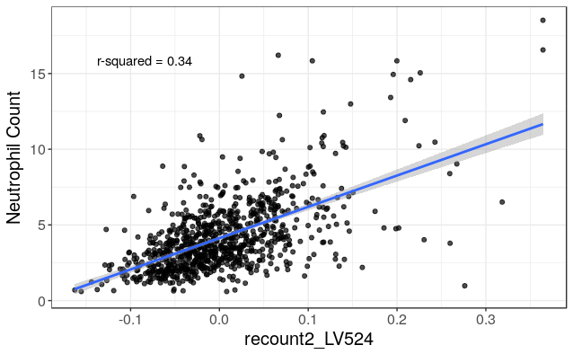

```r
LVScatter(lv = "recount2_LV524", rsq = 0.34)
```

#### LV603

```r
summary(lm(neutro.df$Neutrophil.Count ~ neutro.df$recount2_LV603))
```

```
Call:
lm(formula = neutro.df$Neutrophil.Count ~ neutro.df$recount2_LV603)

Residuals:
    Min      1Q  Median      3Q     Max
-4.1245 -1.1945 -0.2527  0.8522 12.0900

Coefficients:
                         Estimate Std. Error t value Pr(>|t|)
(Intercept)               4.00409    0.06612   60.56   <2e-16 ***
neutro.df$recount2_LV603 11.09268    0.50550   21.94   <2e-16 ***
---
Signif. codes:  0 ‘***’ 0.001 ‘**’ 0.01 ‘*’ 0.05 ‘.’ 0.1 ‘ ’ 1

Residual standard error: 1.916 on 851 degrees of freedom
Multiple R-squared:  0.3614,    Adjusted R-squared:  0.3606
F-statistic: 481.5 on 1 and 851 DF,  p-value: < 2.2e-16
```

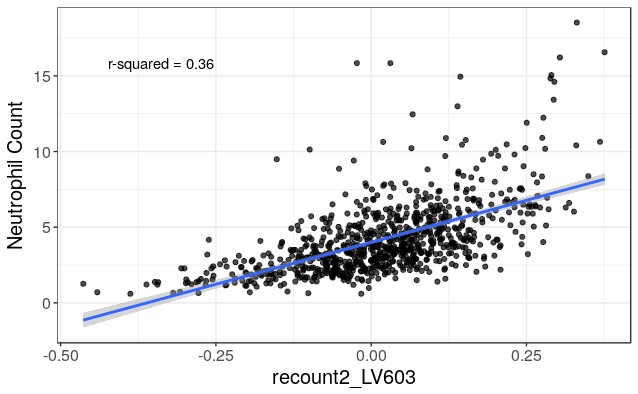

```r
LVScatter(lv = "recount2_LV603", rsq = 0.36)
```

#### LV985

```r
summary(lm(neutro.df$Neutrophil.Count ~ neutro.df$recount2_LV985))
```

```
Call:
lm(formula = neutro.df$Neutrophil.Count ~ neutro.df$recount2_LV985)

Residuals:
    Min      1Q  Median      3Q     Max
-4.7147 -1.2945 -0.3547  0.8808 12.6068

Coefficients:
                         Estimate Std. Error t value Pr(>|t|)
(Intercept)               4.06785    0.06814   59.70   <2e-16 ***
neutro.df$recount2_LV985 14.77640    0.74475   19.84   <2e-16 ***
---
Signif. codes:  0 ‘***’ 0.001 ‘**’ 0.01 ‘*’ 0.05 ‘.’ 0.1 ‘ ’ 1

Residual standard error: 1.982 on 851 degrees of freedom
Multiple R-squared:  0.3163,    Adjusted R-squared:  0.3155
F-statistic: 393.7 on 1 and 851 DF,  p-value: < 2.2e-16
```

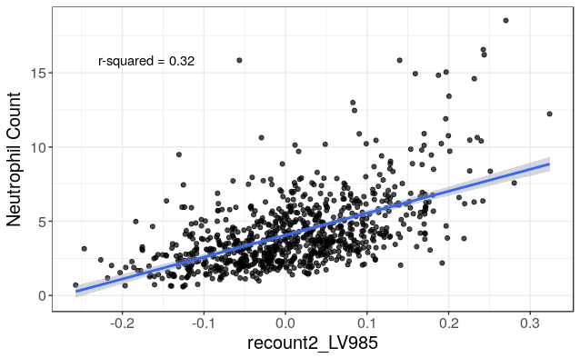

```r
LVScatter(lv = "recount2_LV985", rsq = 0.32)
```

The neutrophil-associated LVs from the recount2 model generally perform as well as the neutrophil-associated LVs from the SLE WB PLIER model.

We’ll plot the results from `SLE WB LV87` and `recount2 LV603` together because these are both LVs that are not significantly associated with monocyte signatures and have high AUC for the neutrophil gene sets.

```r
sle.plot <- LVScatter("LV87", rsq = 0.29) +
  ggplot2::labs(title = "SLE WB PLIER model") +
  ggplot2::theme(plot.title = ggplot2::element_text(hjust = 0.5,
                                                    face = "bold"))
```

```r
recount.plot <- LVScatter("recount2_LV603", rsq = 0.36) +
  ggplot2::labs(title = "recount2 PLIER model") +
  ggplot2::theme(plot.title = ggplot2::element_text(hjust = 0.5,
                                                    face = "bold"))
```

```r
pdf(file.path(plot.dir, "Neutrophil_LV_model_comparison.pdf"), width = 14,
    height = 7)
gridExtra::grid.arrange(sle.plot, recount.plot, ncol = 2)
dev.off()
```

#### Correlation between LV values from different models

```r
summary(lm(neutro.df$LV87 ~ neutro.df$recount2_LV603))
```

```
Call:
lm(formula = neutro.df$LV87 ~ neutro.df$recount2_LV603)

Residuals:
     Min       1Q   Median       3Q      Max
-0.66051 -0.07107  0.01107  0.08593  0.33998

Coefficients:
                          Estimate Std. Error t value Pr(>|t|)
(Intercept)              -0.016814   0.004702  -3.576 0.000369 ***
neutro.df$recount2_LV603  2.753708   0.035945  76.610  < 2e-16 ***
---
Signif. codes:  0 ‘***’ 0.001 ‘**’ 0.01 ‘*’ 0.05 ‘.’ 0.1 ‘ ’ 1

Residual standard error: 0.1362 on 851 degrees of freedom
Multiple R-squared:  0.8734,    Adjusted R-squared:  0.8732
F-statistic:  5869 on 1 and 851 DF,  p-value: < 2.2e-16
```

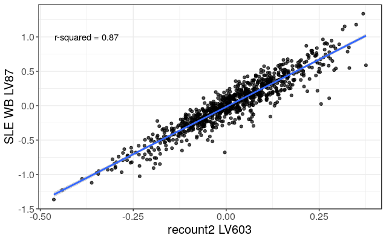

```r
ggplot2::ggplot(neutro.df, ggplot2::aes(x = recount2_LV603,
                                        y = LV87)) +
    ggplot2::geom_point(alpha = 0.7) +
    ggplot2::geom_smooth(method = "lm") +
    ggplot2::theme_bw() +
    ggplot2::labs(x = "recount2 LV603", y = "SLE WB LV87") +
    ggplot2::theme(legend.position = "none",
                   text = ggplot2::element_text(size = 15)) +
    ggplot2::annotate(geom = "text", x = -0.375, y = 1,
                      label = "r-squared = 0.87")
```

```r
plot.file <-
  file.path(plot.dir, "Banchereau_neutrophil_count_LV87_v_recLV603_scatter.png")
ggplot2::ggsave(plot.file, plot = ggplot2::last_plot())
```

#### Distribution of correlation values

There are 987 latent variables from the recount2 PLIER model. Could any one of them be well-correlated with the Banchereau, et al. neutrophil counts by chance?

```r
recount.b.t <- as.data.frame(t(sle.recount.b))
recount.b.t <- tibble::rownames_to_column(recount.b.t, "Sample")
head(recount.b.t)
```

|  | Sample | 1,REACTOME_MRNA_SPLICING | 2,SVM Monocytes | 3,REACTOME_TRANSMISSION_ACROSS_CHEMICAL_SYNAPSES | 4,REACTOME_NEURONAL_SYSTEM | LV 5 | LV 6 | 7,IRIS_Neutrophil-Resting | 8,KEGG_PPAR_SIGNALING_PATHWAY | LV 9 | 10,SVM Macrophages M0 | LV 11 | 12,DMAP_MEGA2 | 13,REACTOME_GLUCOSE_METABOLISM | LV 14 | LV 15 | LV 16 | 17,SVM NK cells resting | 18,REACTOME_PHASE1_FUNCTIONALIZATION_OF_COMPOUNDS | LV 19 | 20,KEGG_NEUROACTIVE_LIGAND_RECEPTOR_INTERACTION | LV 21 | 22,KEGG_PPAR_SIGNALING_PATHWAY | LV 23 | 24,PID_DELTANP63PATHWAY | 25,SVM Macrophages M1 | 26,SVM Macrophages M2 | 27,REACTOME_CELL_JUNCTION_ORGANIZATION | LV 28 | … |
| --- | --- | --- | --- | --- | --- | --- | --- | --- | --- | --- | --- | --- | --- | --- | --- | --- | --- | --- | --- | --- | --- | --- | --- | --- | --- | --- | --- | --- | --- | --- |
| 1 | GSM955680_DNA10204-001.CEL | -0.03395290 | 0.081035061 | 0.03815818 | 0.032763258 | 0.0002871415 | 0.03803374 | 0.002862615 | 0.03437228 | -0.029724416 | -0.052150461 | -0.02447005 | -0.0203536070 | 0.04364213 | -0.001763023 | -0.003842851 | 0.02195738 | 0.056438123 | -0.014018467 | -0.0004355455 | 0.017030292 | 0.034561849 | 0.015299280 | -0.033005760 | -0.035103233 | -0.06465661 | -0.004915572 | -0.013179362 | 0.04549313 | … |
| 2 | GSM955681_DNA10204-003.CEL | -0.07161370 | 0.091564195 | 0.05081163 | 0.021167754 | 0.0339319070 | 0.04323961 | 0.070804246 | 0.04021508 | -0.050874509 | 0.003789719 | -0.01214339 | 0.0209441465 | 0.06722221 | 0.012674726 | 0.012781267 | 0.02116790 | -0.007466842 | -0.002887549 | -0.0119229905 | 0.022920366 | 0.037715917 | 0.014613857 | -0.007505417 | -0.004016677 | -0.06496922 | -0.001777833 | 0.017758785 | 0.05133480 | … |
| 3 | GSM955682_DNA10204-005.CEL | -0.06906802 | 0.065179338 | 0.02704655 | -0.003828151 | 0.0382327216 | 0.04421637 | 0.067935900 | 0.05067575 | -0.069085575 | 0.017946948 | -0.04410002 | 0.0837550615 | 0.03475007 | 0.041493942 | 0.003201421 | 0.01536979 | -0.025475818 | 0.001457680 | -0.0206546768 | 0.014859086 | 0.037439031 | 0.004895231 | 0.010043317 | -0.007093417 | -0.06333000 | -0.010873832 | -0.029752045 | 0.05913749 | … |
| 4 | GSM955683_DNA10204-007.CEL | -0.07485566 | 0.003569584 | 0.03903680 | 0.040308136 | -0.0067368763 | 0.02015887 | 0.087291345 | 0.04450900 | -0.040496172 | -0.017537500 | -0.01654550 | -0.0006390414 | 0.04877991 | 0.006335591 | 0.009710508 | 0.04236935 | -0.023242906 | 0.031029185 | -0.0119920441 | 0.052188902 | -0.033212688 | -0.010504994 | -0.015420980 | -0.016822467 | -0.05418043 | -0.040304756 | -0.005424158 | 0.05293383 | … |
| 5 | GSM955684_DNA10204-011.CEL | 0.00297101 | 0.064716673 | 0.08735997 | 0.006276166 | 0.0275628811 | 0.02849317 | 0.059305735 | 0.06744268 | 0.007963506 | -0.023872458 | 0.01946408 | 0.0056394894 | 0.06907233 | 0.015415903 | 0.020122757 | 0.04956571 | -0.088323220 | 0.053980834 | 0.0245638909 | -0.015665133 | 0.006426886 | 0.026816464 | -0.004484725 | 0.017412511 | -0.07003719 | -0.002595931 | -0.009474623 | 0.10831921 | … |
| 6 | GSM955685_DNA10204-013.CEL | -0.02242306 | 0.011256099 | 0.05074386 | 0.014725124 | 0.0085276462 | 0.01804932 | 0.053875941 | 0.06243581 | -0.015257231 | -0.046961353 | -0.01158785 | -0.0428037783 | 0.04268182 | 0.016524776 | 0.007793891 | 0.01984551 | -0.006224110 | 0.012579190 | -0.0005218677 | 0.008679888 | 0.009885796 | -0.011136560 | -0.020627314 | -0.010523418 | -0.08452997 | -0.011629055 | 0.013198309 | 0.05739662 | … |

```r
b.count.df <- dplyr::inner_join(x = neutro.df[, c("Sample",
                                                  "Neutrophil.Count")],
                                y = recount.b.t, by = "Sample")
```

```r
rsq.all.lv <- (cor(x = b.count.df$Neutrophil.Count,
                   y = b.count.df[, 3:ncol(b.count.df)])) ^ 2
rsq.df <- as.data.frame(matrix(rsq.all.lv, ncol = 1))
colnames(rsq.df) <- "r.squared"
```

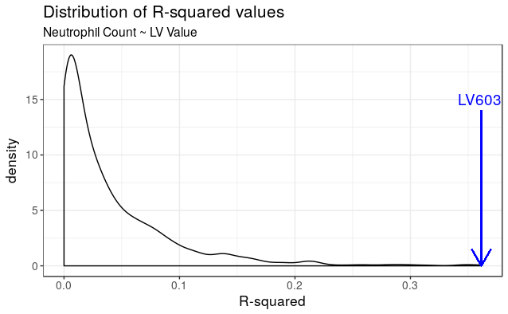

```r
ggplot2::ggplot(rsq.df, ggplot2::aes(x = r.squared)) +
  ggplot2::geom_density() +
  ggplot2::geom_segment(mapping = ggplot2::aes(x = rsq.df[603, ],
                                               xend = rsq.df[603, ],
                                               y = 14, yend = 0),
                        arrow = grid::arrow(),
                        colour = "blue") +
  ggplot2::theme_bw() +
  ggplot2::theme(text = ggplot2::element_text(size = 13)) +
  ggplot2::labs(x = "R-squared", subtitle = "Neutrophil Count ~ LV Value",
                title = "Distribution of R-squared values") +
  ggplot2::annotate(geom = "text", x = 0.36, y = 15, colour = "blue",
                    label = "LV603", size = 5)
```

```r
plot.file <-
  file.path(plot.dir, "Banchereau_neutrophil_count_recount2_lv_rsq.png")
ggplot2::ggsave(plot.file, plot = ggplot2::last_plot())
```

```r
which.max(rsq.all.lv)
```

```
[1] 603
```

`recount2 LV603` has the highest R-squared with the Banchereau, et al. neutrophil counts.

### Plasma cell

```r
# get LV951 into data.frame form
plasma.lv.df <- as.data.frame(cbind(colnames(sle.recount.b),
                                    sle.recount.b[951, ]))
colnames(plasma.lv.df) <- c("Sample", "recount2_LV951")
```

```r
# join with SLE WB results
plasma.df <- dplyr::inner_join(sle.plasma.df, plasma.lv.df, by = "Sample") %>%
  dplyr::mutate(recount2_LV951 = as.numeric(as.character(recount2_LV951)))
```

```
Column `Sample` joining character vector and factor, coercing into character vector
```

```r
head(plasma.df)
```

| Sample | LV52 | LV136 | Disease.Activity | recount2_LV951 |
| --- | --- | --- | --- | --- |
| GSM1594268 | 0.354004559 | -0.029880425 | DA3 | 0.03678165 |
| GSM1594269 | -0.063266973 | -0.086564899 | DA1 | -0.01169214 |
| GSM1594270 | 0.498779479 | -0.176373873 | DA3 | 0.07301065 |
| GSM1594271 | -0.144102056 | 0.050043856 | DA2 | -0.04965789 |
| GSM1594272 | 0.008078649 | -0.006313806 | DA3 | -0.01049371 |
| GSM1594273 | -0.126391548 | -0.035346313 | DA2 | -0.01730733 |

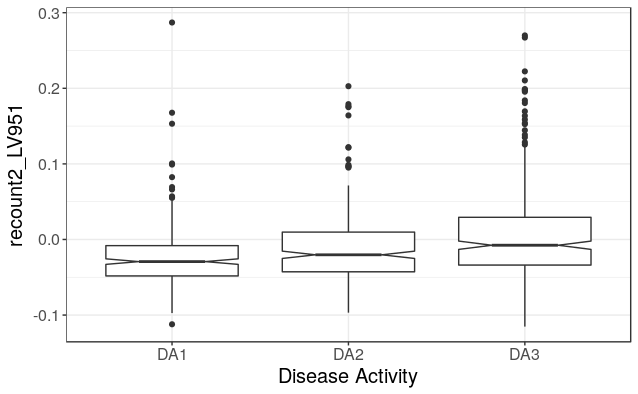

```r
plasma.df %>%
  ggplot2::ggplot(ggplot2::aes(x = Disease.Activity,
                               y = recount2_LV951)) +
  ggplot2::geom_boxplot(notch = TRUE) +
  ggplot2::theme_bw() +
  ggplot2::labs(x = "Disease Activity") +
  ggplot2::theme(text = ggplot2::element_text(size = 15))
```

```r
# check for statistical significance
# (pairwise t-test is consistent with original publication as far as I can tell)
pairwise.t.test(x = plasma.df$recount2_LV951,
                g = plasma.df$Disease.Activity,
                p.adjust.method = "bonferroni")
```

```
    Pairwise comparisons using t tests with pooled SD

data:  plasma.df$recount2_LV951 and plasma.df$Disease.Activity

    DA1     DA2
DA2 0.047   -
DA3 5.0e-13 2.3e-06

P value adjustment method: bonferroni
```

This is highly similar to what we saw in `06-sle-wb_cell_type`.

Now we’ll plot the recount2 (`recount2_LV951`) and SLE WB model (`LV52`) results side by side as we did above with the neutrophil scatterplots.

```r
sle.plot <- plasma.df %>%
  ggplot2::ggplot(ggplot2::aes(x = Disease.Activity,
                               y = LV52)) +
  ggplot2::geom_boxplot(notch = TRUE) +
  ggplot2::theme_bw() +
  ggplot2::labs(x = "Disease Activity",
                title = "SLE WB PLIER model") +
  ggplot2::theme(plot.title = ggplot2::element_text(hjust = 0.5,
                                                    face = "bold")) +
  ggplot2::theme(text = ggplot2::element_text(size = 15))
```

```r
recount.plot <- plasma.df %>%
  ggplot2::ggplot(ggplot2::aes(x = Disease.Activity,
                               y = recount2_LV951)) +
  ggplot2::geom_boxplot(notch = TRUE) +
  ggplot2::theme_bw() +
  ggplot2::labs(x = "Disease Activity",
                title = "recount2 PLIER model") +
  ggplot2::theme(plot.title = ggplot2::element_text(hjust = 0.5,
                                                    face = "bold")) +
  ggplot2::theme(text = ggplot2::element_text(size = 15))
```

```r
pdf(file.path(plot.dir, "Plasma_cell_LV_model_comparison.pdf"), width = 14,
    height = 7)
gridExtra::grid.arrange(sle.plot, recount.plot, ncol = 2)
dev.off()
```